# Exploring the BRFSS data

## Setup

### Load packages

```r
library(ggplot2)
library(dplyr)
```

### Load data

The data used for this research is Behavioral Risk Factor Surveillance System (BRFSS) for year 2013. More information about the data could be found at http://www.cdc.gov/brfss/

```r
load("brfss2013.RData")
```

## Part 0: Question in mind

In this research we will try to find if a relation exist between education level of an individual and chronic diseases. We will primarily be considering three diseases :

- Heart Related Chronic Diseases(HRCD) which includes
  - High Blood Pressure
  - Heart Attack
  - Angina or Coronary Heart Disease
- Cancer
  - Skin Cancer
  - Any other type of Cancer
- Depressive disorder

The reasoning behind choosing a demographic variable like education level for this research is to look if better awareness towards the diseases has any impact on the occurrence of these diseases. It is assumed that a better education level would imply better awareness towards the risk factors that contribute towards these diseases as well as better knowledge of mitigating them.

Since all the results will come from a random sample, they would be generalizable. But, since this is not a controlled experiment we cannot derive causation relationship between variables.

## Part 1: Data

The variable “bphigh4” has 4 levels excluding NA. For our analysis everything other than “Yes” should be grouped as “no”. Hence, we create a new variable “hbp” with yes and no as levels.

```r
brfss2013 <- brfss2013 %>%
  mutate(hbp = ifelse(bphigh4=="Yes", "yes","no"))

brfss2013 %>% group_by(hbp) %>% summarize(count=n())
```

```
## # A tibble: 3 × 2
##     hbp  count
##   <chr>  <int>
## 1    no 291434
## 2   yes 198921
## 3  <NA>   1420
```

We now create the variable HRCD which has value “yes” if an individual has either one of the three conditions - high blood pressure, ever had heart attack or angina.

```r
brfss2013 <- brfss2013 %>%
  mutate(HRCD = ifelse(hbp == "yes" | cvdinfr4 == "Yes" | cvdcrhd4 == "Yes", "yes","no"))
brfss2013 %>% group_by(HRCD) %>% summarize(count=n())
```

```
## # A tibble: 3 × 2
##    HRCD  count
##   <chr>  <int>
## 1    no 278767
## 2   yes 210152
## 3  <NA>   2856
```

Note that the above variable HRCD has a value “yes” if any of the three variables, hbp, cvdinfr4 or cvdcrhd4 has a value of yes but it has a value NA if at least one of the three is NA and none of the remaining is “yes”.

```r
brfss2013 %>% group_by(hbp,cvdinfr4,cvdcrhd4,HRCD) %>% summarize(count=n())
```

```
## Source: local data frame [27 x 5]
## Groups: hbp, cvdinfr4, cvdcrhd4 [?]
##
##      hbp cvdinfr4 cvdcrhd4  HRCD  count
##    <chr>   <fctr>   <fctr> <chr>  <int>
## 1     no      Yes      Yes   yes   2770
## 2     no      Yes       No   yes   4299
## 3     no      Yes       NA   yes    305
## 4     no       No      Yes   yes   3625
## 5     no       No       No    no 278767
## 6     no       No       NA  <NA>    755
## 7     no       NA      Yes   yes     93
## 8     no       NA       No  <NA>    632
## 9     no       NA       NA  <NA>    188
## 10   yes      Yes      Yes   yes  11149
## # ... with 17 more rows
```

We also create a variable HC which holds a value “yes” if either of the variable CHCSCNCR or CHCOCNCR holds a value of “yes”, i.e. if the person ever had or has skin or any other type of cancer.

```r
brfss2013 <- brfss2013 %>%
  mutate(HC=ifelse(chcscncr == "Yes" | chcocncr == "Yes","yes","no"))
brfss2013 %>% group_by(chcscncr,chcocncr,HC) %>% summarize(count=n())
```

```
## Source: local data frame [9 x 4]
## Groups: chcscncr, chcocncr [?]
##
##   chcscncr chcocncr    HC  count
##     <fctr>   <fctr> <chr>  <int>
## 1      Yes      Yes   yes   9918
## 2      Yes       No   yes  35390
## 3      Yes       NA   yes    138
## 4       No      Yes   yes  36947
## 5       No       No    no 407304
## 6       No       NA  <NA>    769
## 7       NA      Yes   yes    209
## 8       NA       No  <NA>    859
## 9       NA       NA  <NA>    241
```

```r
brfss2013 %>% group_by(HC) %>% summarize(count=n())
```

```
## # A tibble: 3 × 2
##      HC  count
##   <chr>  <int>
## 1    no 407304
## 2   yes  82602
## 3  <NA>   1869
```

We also create new variable for plotting purpose that, for each education level, count of individuals who had or didn’t have Chronic diseases. For visualization purpose, we also develop an Education Level Index :

- Ed Lev. 1 -> Never attended school or only kindergarten
- Ed Lev. 2 -> Grades 1 through 8 (Elementary)
- Ed Lev. 3 -> Grades 9 though 11 (Some high school)
- Ed Lev. 4 -> Grade 12 or GED (High school graduate)
- Ed Lev. 5 -> College 1 year to 3 years (Some college or technical school)
- Ed Lev. 6 -> College 4 years or more (College graduate)

These will be used as categories in the plots.

## Part 2: Research questions

**Research quesion 1:** Question 1 is related to exploring relation between education level of people and their chances of developing heart related diseases.

**Research quesion 2:** Question 2 is about exploring relation between education levels of people and their chances of developing cancer. If there is any correlation between different educational section of society and their chances of developing cancer.

**Research quesion 3:** Question 3 explores the same relation with depressive disorder. If there is a certain section of society, divided based on education levels, that is more prone to depressive disorders or is there a correlation between education level and depressive disorder.

## Part 3: Exploratory data analysis

**Research quesion 1:**

Heart Related Chronic Diseases (involves 4 variables) -

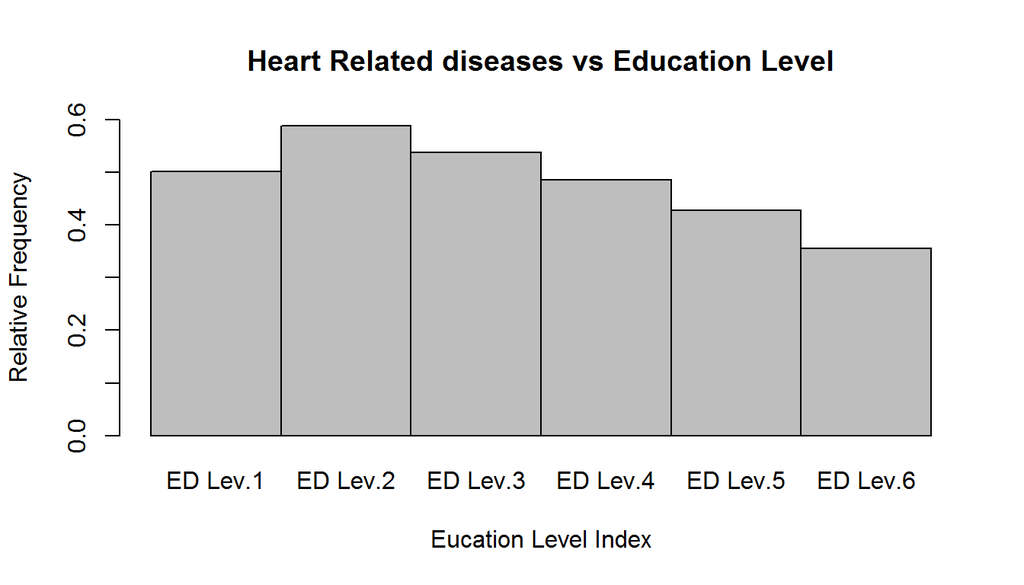

```r
indx <- c("ED Lev.1","ED Lev.2","ED Lev.3","ED Lev.4","ED Lev.5","ED Lev.6")
var1 <- brfss2013 %>% filter(!is.na(educa),!is.na(HRCD),HRCD=="yes") %>%
 group_by(educa,HRCD) %>% summarize(count_yes=n())
var2 <- brfss2013 %>% filter(!is.na(educa),!is.na(HRCD),HRCD=="no") %>%
 group_by(educa,HRCD) %>% summarize(count=n())
HRCD_vs_educa <- var1 %>% mutate(count_no=count_yes)
HRCD_vs_educa$count_no <- var2$count
HRCD_vs_educa <- HRCD_vs_educa %>% mutate(tot_count=count_yes+count_no)
HRCD_vs_educa <- HRCD_vs_educa %>% mutate(freq_yes=count_yes/tot_count)
HRCD_vs_educa <- HRCD_vs_educa %>% mutate(freq_no=count_no/tot_count)
barplot(HRCD_vs_educa$freq_yes,names.arg = indx,ylim=c(0.0,0.6),space=0,xlab="Eucation Level Index",ylab="Relative Frequency",main="Heart Related diseases vs Education Level")
```

```r
HRCD_vs_educa <- HRCD_vs_educa %>% mutate(perc_yes=freq_yes*100)
HRCD_vs_educa[,c('educa','perc_yes')]
```

```
## Source: local data frame [6 x 2]
## Groups: educa [6]
##
##                                                          educa perc_yes
##                                                         <fctr>    <dbl>
## 1                   Never attended school or only kindergarten 50.22355
## 2                              Grades 1 through 8 (Elementary) 58.87292
## 3                        Grades 9 though 11 (Some high school) 53.78127
## 4                       Grade 12 or GED (High school graduate) 48.55221
## 5 College 1 year to 3 years (Some college or technical school) 42.74995
## 6                   College 4 years or more (College graduate) 35.48867
```

The chart shows an expected trend. There is a general decrease in percentage of people developing heart related diseases with increase in education level. Since it is well established that life style and food habits have a lot of impact on heart related diseases, people with higher education levels could be more aware of these habits and included them in their lifestyle. This is a generalizable result coming from a random sample. The relationship between the variables is only a negative association. No causation is implied here.

**Research quesion 2:**

Cancer (involves 3 variables) -

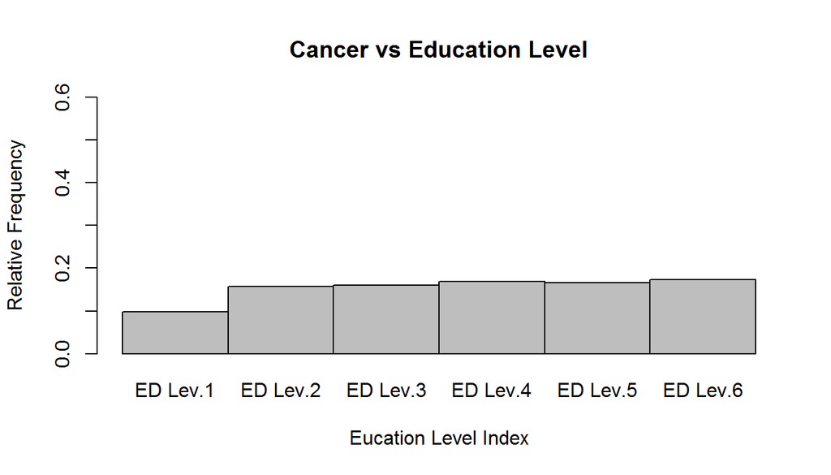

```r
var1 <- brfss2013 %>% filter(!is.na(educa),!is.na(HC),HC=="yes") %>%
 group_by(educa) %>% summarize(count_yes=n())
var2 <- brfss2013 %>% filter(!is.na(educa),!is.na(HC),HC=="no") %>%
 group_by(educa) %>% summarize(count_no=n())
HC_vs_educa <- var1 %>% mutate(count_no=count_yes)
HC_vs_educa$count_no=var2$count_no
HC_vs_educa <- HC_vs_educa %>% mutate(tot_count=count_yes+count_no)
HC_vs_educa <- HC_vs_educa %>% mutate(freq_yes=count_yes/tot_count)
HC_vs_educa <- HC_vs_educa %>% mutate(freq_no=count_no/tot_count)
barplot(HC_vs_educa$freq_yes,names.arg = indx,ylim=c(0.0,0.6),space=0,xlab="Eucation Level Index",ylab="Relative Frequency",main="Cancer vs Education Level")
```

```r
HC_vs_educa <- HC_vs_educa %>% mutate(perc_yes=freq_yes*100)
HC_vs_educa[,c('educa','perc_yes')]
```

```
## # A tibble: 6 × 2
##                                                          educa  perc_yes
##                                                         <fctr>     <dbl>
## 1                   Never attended school or only kindergarten  9.821429
## 2                              Grades 1 through 8 (Elementary) 15.680384
## 3                        Grades 9 though 11 (Some high school) 16.056751
## 4                       Grade 12 or GED (High school graduate) 16.888443
## 5 College 1 year to 3 years (Some college or technical school) 16.611328
## 6                   College 4 years or more (College graduate) 17.340008
```

We see that percentage of people developing cancer remains mostly constant across education level with a slight dip in level 1 (never attended school or only kindergarten). There are two possible reasons for this trend, first, it is not fully established within scientific community if dietary or other daily habits have any impact on possibility of one developing cancer or not. The other explanation is presence of confounding variables like smoking etc. that have not been considered in this research.

**Research quesion 3:**

Depression (involves 2 variables)

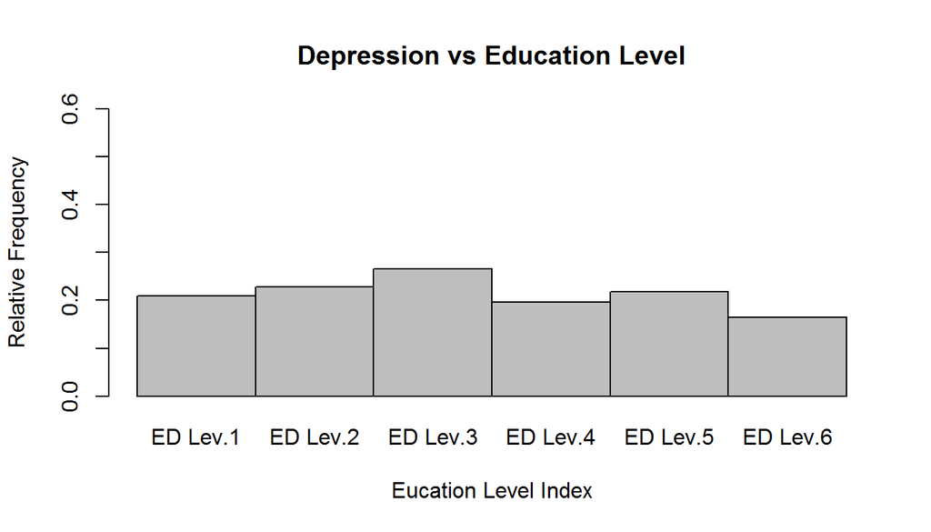

```r
var1 <- brfss2013 %>% filter(!is.na(educa),!is.na(addepev2),addepev2=="Yes") %>%
 group_by(educa) %>% summarize(count_yes=n())
var2 <- brfss2013 %>% filter(!is.na(educa),!is.na(addepev2),addepev2=="No") %>%
 group_by(educa) %>% summarize(count_no=n())
DEP_vs_educa <- var1 %>% mutate(count_no=count_yes)
DEP_vs_educa$count_no <- var2$count_no
DEP_vs_educa <- DEP_vs_educa %>% mutate(tot_count=count_yes+count_no)
DEP_vs_educa <- DEP_vs_educa %>% mutate(freq_yes=count_yes/tot_count)
DEP_vs_educa <- DEP_vs_educa %>% mutate(freq_no=count_no/tot_count)
barplot(DEP_vs_educa$freq_yes,names.arg = indx,ylim=c(0.0,0.6),space=0,xlab="Eucation Level Index",ylab="Relative Frequency",main="Depression vs Education Level")
```

```r
DEP_vs_educa <- DEP_vs_educa %>% mutate(perc_yes=freq_yes*100)
DEP_vs_educa[,c('educa','perc_yes')]
```

```
## # A tibble: 6 × 2
##                                                          educa perc_yes
##                                                         <fctr>    <dbl>
## 1                   Never attended school or only kindergarten 20.87087
## 2                              Grades 1 through 8 (Elementary) 22.86102
## 3                        Grades 9 though 11 (Some high school) 26.61891
## 4                       Grade 12 or GED (High school graduate) 19.63117
## 5 College 1 year to 3 years (Some college or technical school) 21.73393
## 6                   College 4 years or more (College graduate) 16.46137
```

The plot shows that slightly higher percentage of people develop depression in mid education level segment (High School) than other education level segments. The difference is not too high in my opinion and should be checked for random or statistical error.